# Exercise 6: Multivariate Optimization 1

[Optimization in Machine Learning](https://slds-lmu.github.io/website_optimization/)

**Reproducibility**

Produced with Python 3.10 and R 4.4.1. To reproduce, install the pinned package versions below.

**Python**

```bash
pip install numpy==2.0.2 matplotlib==3.10.8
```

**R**

```r
install.packages("remotes")
remotes::install_version("ggplot2", "3.5.1")
remotes::install_version("gridExtra", "2.3")
```

## Setup

You are given the following data situation:

**R**

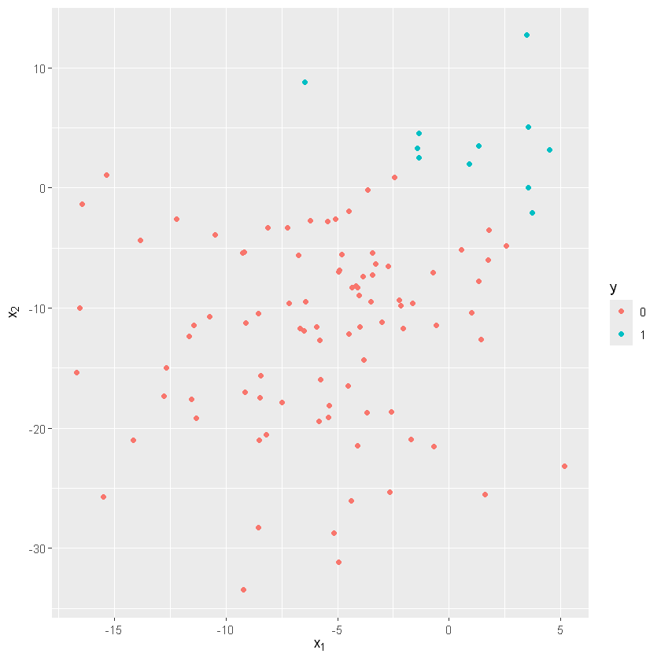

```r
library(ggplot2)
library(gridExtra)

set.seed(314)
n <- 100
X <- cbind(rnorm(n, -5, 5), rnorm(n, -10, 10))
z <- 2 * X[, 1] + 3 * X[, 2]
pr <- 1 / (1 + exp(-z))
y <- as.integer(pr > 0.5)
df <- data.frame(X = X, y = y)

ggplot(df) +
  geom_point(aes(x = X.1, y = X.2, color = as.factor(y))) +
  xlab(expression(x[1])) +
  ylab(expression(x[2])) +
  labs(colour = "y")
```

**Python**

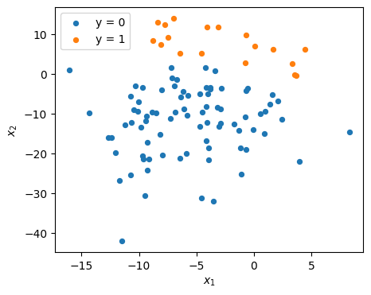

```python
import numpy as np
import matplotlib.pyplot as plt

np.random.seed(314)
n = 100
X = np.column_stack([np.random.normal(-5, 5, n), np.random.normal(-10, 10, n)])
z = 2 * X[:, 0] + 3 * X[:, 1]
pr = 1 / (1 + np.exp(-z))
y = (pr > 0.5).astype(int)

fig, ax = plt.subplots(figsize=(5, 4))
for label in (0, 1):
    mask = y == label
    ax.scatter(X[mask, 0], X[mask, 1], label=f"y = {label}", s=18)
ax.set_xlabel(r"$x_1$"); ax.set_ylabel(r"$x_2$")
ax.legend()
plt.show()
```

**Note**

**R vs. Python parity.** R’s `set.seed(314)` and Python’s `np.random.seed(314)` use *different* RNGs. The data above (and consequently the GD trajectories below) differ between languages. Both implementations are correct; only the underlying data differs. Compare *algorithmic behavior* (divergence, convergence, backtracking adaptation) rather than expecting numerically identical $\boldsymbol{\theta}$ values.

In the following we want to estimate a logistic regression *without intercept* via gradient descent.

*Note: We use vanilla GD for educational purposes; in practice more sophisticated algorithms are typically preferred.*

## (a) Complete separation makes the empirical risk unbounded below

The data above is **completely separable**: the two classes can be perfectly classified with a linear classifier. Show that in this situation, if $\tilde{\boldsymbol{\theta}}$ perfectly classifies the data then

$$\mathcal{R}_\text{emp}(\tilde{\boldsymbol{\theta}}) > \mathcal{R}_\text{emp}(\alpha \tilde{\boldsymbol{\theta}}) \quad \text{for all } \alpha > 1.$$

*Implication:* the per-observation log-loss can be driven arbitrarily low by scaling $\boldsymbol{\theta}$, so the empirical risk has no finite minimum.

## (b) Visualize the empirical risk

Visualize $\mathcal{R}_\text{emp}$ on $[-1, 4] \times [-1, 4]$.

## (c) Gradient of the empirical risk

Find $\nabla_{\boldsymbol{\theta}} \mathcal{R}_\text{emp}$ for arbitrary $\boldsymbol{\theta}$.

## (d) Vanilla gradient descent

Solve the logistic regression via gradient descent. Use step size $\alpha = 0.01$, starting point $\boldsymbol{\theta}^{[0]} = (0, 0)^\top$, and train for $500$ steps. Repeat with $\alpha = 0.02$. Explain what you observe.

*Hint:* recall (a).

## (e) Add L2 regularization

Repeat (d), but minimize $\lambda\|\boldsymbol{\theta}\|^2 + \mathcal{R}_\text{emp}(\boldsymbol{\theta})$ with $\lambda = 1$. What changes?

## (f) Visualize the regularized empirical risk

Visualize the regularized empirical risk $\lambda\|\boldsymbol{\theta}\|^2 + \mathcal{R}_\text{emp}(\boldsymbol{\theta})$ on $[-1, 4] \times [-1, 4]$ with $\lambda = 1$.

## (g) Gradient descent with backtracking line search

Repeat (e) but with **backtracking line search**: at each step, propose $\boldsymbol{\theta}_{\text{prop}} = \boldsymbol{\theta} - \alpha \nabla f(\boldsymbol{\theta})$ and accept it if it satisfies the Armijo condition

$$f(\boldsymbol{\theta}_{\text{prop}}) \leq f(\boldsymbol{\theta}) - \gamma\, \alpha\, \|\nabla f(\boldsymbol{\theta})\|^2,$$

otherwise shrink $\alpha \leftarrow \tau \alpha$ and try again. Use $\gamma = 0.9$, $\tau = 0.5$.

*Note:* the trace below visualizes from iteration $t = 1$ (after one backtracking step), not from the starting point $\boldsymbol{\theta}^{[0]} = (0, 0)^\top$.